# Autoregressive Integrated Moving Average (ARIMA)

An autoregressive integrated moving average (ARIMA) model is a generalization of an autoregressive moving average (ARMA) model. ARIMA models are applied in some cases where data show evidence of non-stationarity, where an initial differencing step (corresponding to the "integrated" part of the model) can be applied one or more times to eliminate the non-stationarity.  
Non-seasonal ARIMA models are generally denoted ARIMA(p,d,q) where parameters p, d, and q are non-negative integers, p is the order (number of time lags) of the autoregressive model, d is the degree of differencing (the number of times the data have had past values subtracted), and q is the order of the moving-average model.  
ARIMA models can be estimated following the Box–Jenkins approach:

- test the hypothesis of the stationarity of the series
- if alternative hypothesis is True ⇒ make a stationary series and find degree of differencing (d - the number of times the data have had past values subtracted)
- study ACF (autocorrelation function) and PACF (partial autocorrelation), choose order of 'p' in the model of AR and order of 'q' in the model of MA
- build model ARIMA
- check model quality

*Saakyan Artur*

```python
import pandas as pd
import numpy as np
import datetime
import matplotlib.pyplot as plt

import statsmodels.api as sm
```

```python
# delete all columns except 'Adj Close' and rename
df = pd.read_csv('stock.csv', header=0, index_col=0, parse_dates=True)
df.rename(columns = {'Adj Close': 'stock'}, inplace=True)
df.drop(['Open', 'High', 'Low', 'Close', 'Volume'], 1, inplace=True)
```

```python
# check whether a DataFrame has NaN values
print(df.isnull().values.any())

# first five rows in our DataFrame
df.tail()
```

```
False
```

| Date | stock |
| --- | --- |
| 2013-12-24 | 167.393753 |
| 2013-12-26 | 168.244751 |
| 2013-12-27 | 168.235596 |
| 2013-12-30 | 168.208145 |
| 2013-12-31 | 169.004242 |

# Stationarity of the series

```
Date
2003-01-02    67.009781
2003-01-03    67.215836
2003-01-06    68.400467
2003-01-07    68.231201
2003-01-08    67.245239
Name: stock, dtype: float64
```

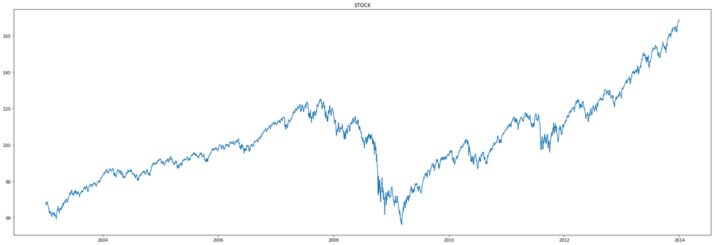

```python
# create ts
ts = df["stock"]
print(ts.head())

# Plot our ts
fig = plt.figure(figsize=(30, 10))
ax1 = fig.add_subplot(111)
ax1.plot(ts, label="STOCK")
plt.title("STOCK")
plt.show()
```

it's clear the process is not stationary, because the variance is not constant.

# Methods for smoothing values and Differencing to Remove Trends

```python
ts_log = np.log(ts) # log-transform
ts_log_diff = ts_log - ts_log.shift()
ts_log_diff.dropna(inplace=True)

moving_avg = ts_log.rolling(14).mean() # moving mean
ts_log_moving_avg_diff = ts_log - moving_avg
ts_log_moving_avg_diff.dropna(inplace=True)
```

```python
# plot autocorrelation and partial autocorrelation
def plot_acf_pacf(timeseries):
    fig = plt.figure(figsize=(12, 8))
    ax1 = fig.add_subplot(211)
    fig = sm.graphics.tsa.plot_acf(timeseries, lags=40, ax=ax1)
    ax2 = fig.add_subplot(212)
    fig = sm.graphics.tsa.plot_pacf(timeseries, lags=40, ax=ax2)
```

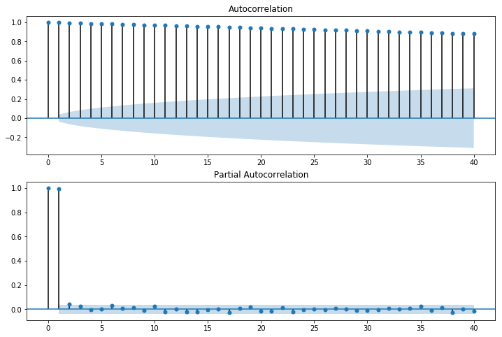

```python
plot_acf_pacf(ts)
```

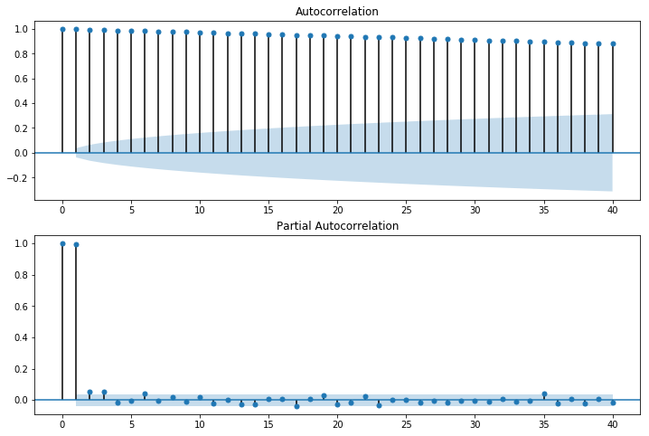

```python
plot_acf_pacf(ts_log)
```

## Dickey—Fuller test

```python
from statsmodels.tsa.stattools import adfuller

def test_stationarity(timeseries):

    # Determing rolling statistics
    rolmean = timeseries.rolling(7).mean()
    rolstd = timeseries.rolling(7).std()

    # Plot rolling statistics
    fig = plt.figure(figsize=(30, 15))
    ax1 = fig.add_subplot(111)
    ax1.plot(timeseries, color='blue', label='Oridinal')
    ax1.plot(rolmean, color='red', label='Rolling Mean')
    ax1.plot(rolstd, color='black', label='Rolling Std')
    plt.legend(loc='best')
    plt.title('Rolling Mean & Standard Deviation')
    plt.show()

    # Perform Dickey-Fuller Test
    dftest = adfuller(timeseries, autolag='AIC')
    return 'Results of Dickey-Fuller Test: p-value = ' + str(dftest[1])
```

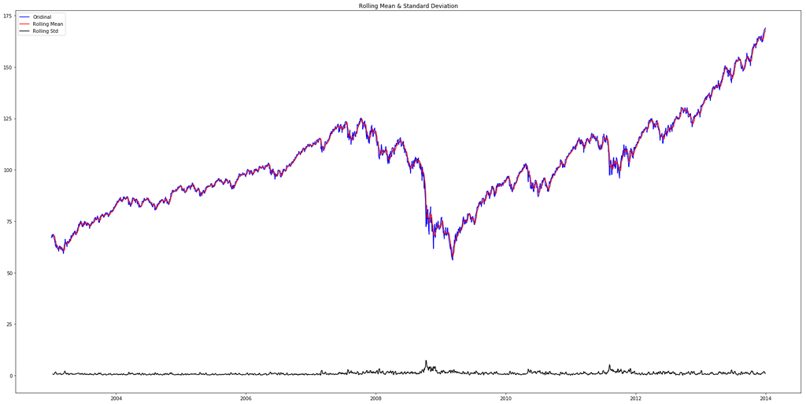

```
'Results of Dickey-Fuller Test: p-value = 0.9655006317385659'
```

```python
# it's obviously: ts isn't stationary
test_stationarity(ts)
```

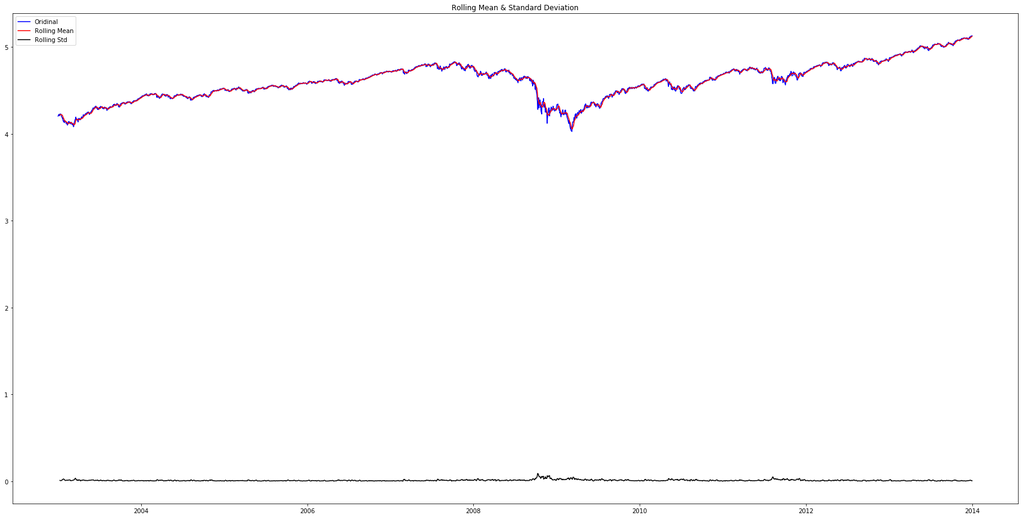

```
'Results of Dickey-Fuller Test: p-value = 0.7238919031685281'
```

```python
# ts_log isn't stationary
test_stationarity(ts_log)
```

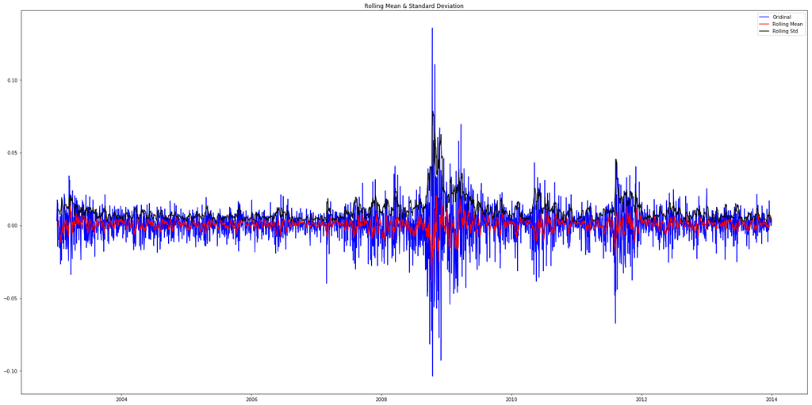

```
'Results of Dickey-Fuller Test: p-value = 2.4685942588453966e-20'
```

```python
# is stationality
test_stationarity(ts_log_diff)
```

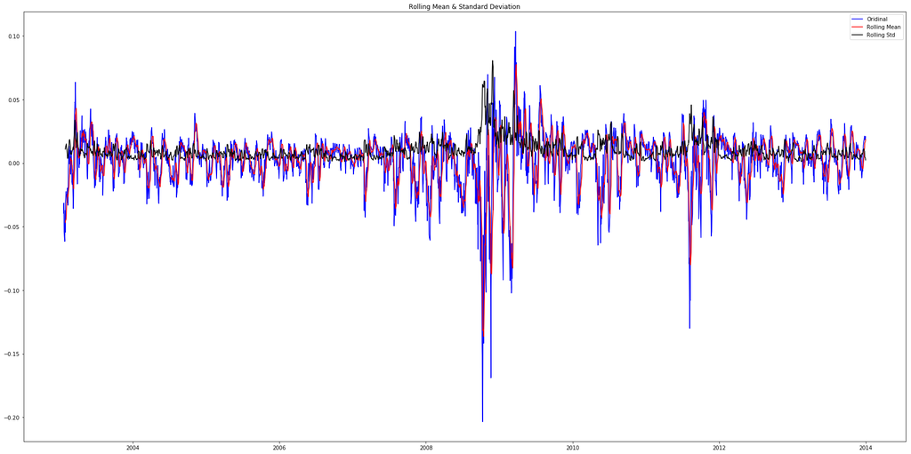

```
'Results of Dickey-Fuller Test: p-value = 2.9916188137978794e-15'
```

```python
# is stationality
test_stationarity(ts_log_moving_avg_diff)
```

##### Conclusion: We can consider all of the converted series because they are stationary (except ts_log).

# Estimation of Seasonality

```python
from statsmodels.tsa.seasonal import seasonal_decompose

def estimation_seasonality(avg_diff):
    decomposition = seasonal_decompose(avg_diff, freq=7)

    trend = decomposition.trend # trend
    seasonal = decomposition.seasonal # seasonal
    residual = decomposition.resid # residual

    fig1 = plt.figure(figsize=(30, 2))
    ax1 = fig1.add_subplot(111)
    ax1.plot(avg_diff, label='Original')
    plt.legend(loc='best')

    fig2 = plt.figure(figsize=(30, 2))
    ax2 = fig2.add_subplot(111)
    ax2.plot(trend, label='Trend')
    plt.legend(loc='best')

    fig3 = plt.figure(figsize=(30, 2))
    ax3 = fig3.add_subplot(111)
    ax3.plot(seasonal, label='Seasonality')
    plt.legend(loc='best')

    fig4 = plt.figure(figsize=(30, 2))
    ax4 = fig4.add_subplot(111)
    ax4.plot(residual, label='Residuals')
    plt.legend(loc='best')

    plt.tight_layout()
    plt.show()

    # The residual of the idea must be stationary, we can test it:
    result = residual
    result.dropna(inplace=True)

    return test_stationarity(result)
```

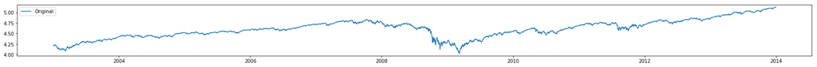

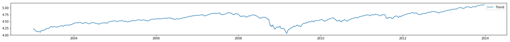

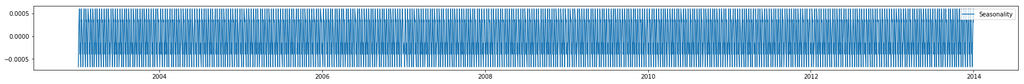

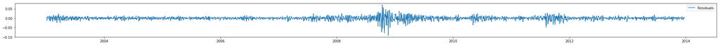

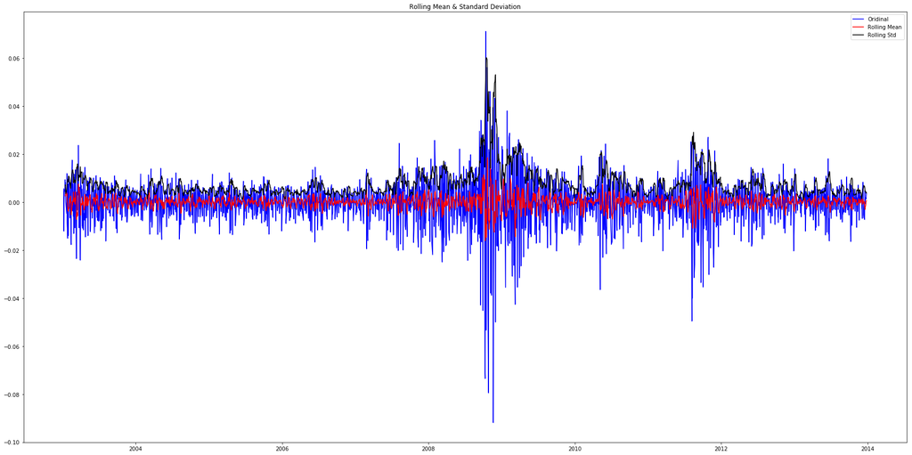

```
'Results of Dickey-Fuller Test: p-value = 6.237064208796537e-30'
```

```python
estimation_seasonality(ts_log)
```

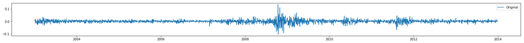

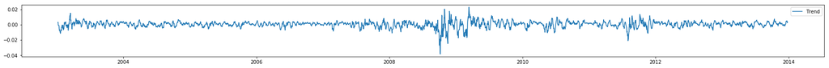

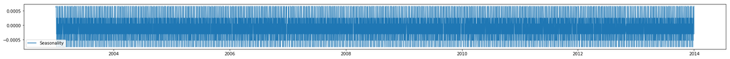

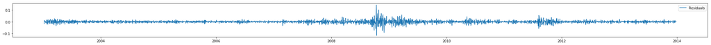

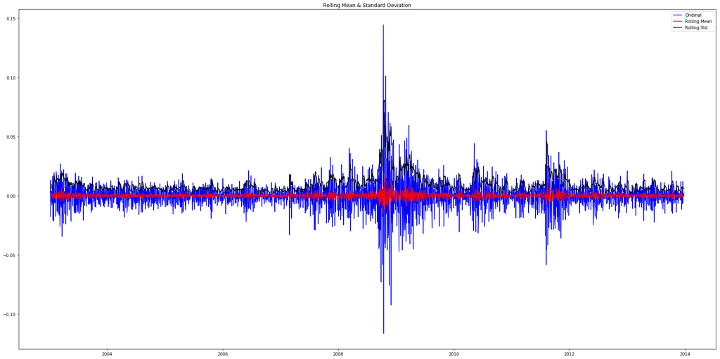

```
'Results of Dickey-Fuller Test: p-value = 0.0'
```

```python
estimation_seasonality(ts_log_diff)
```

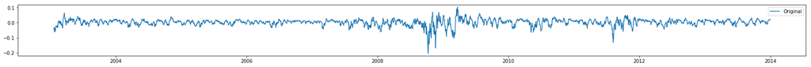

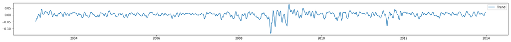

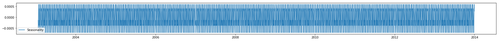

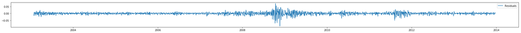

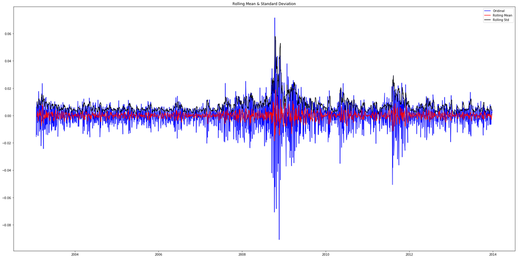

```
'Results of Dickey-Fuller Test: p-value = 0.0'
```

```python
estimation_seasonality(ts_log_moving_avg_diff)
```

##### Conclusion: we can even more strongly consider these series like stationary.

##### (note: here we can see that ts_log is stationary, but we got an other result in Dickey — Fuller test).

# Selection of the parameters p and q

##### The AIC measures how well a model fits the data while taking into account the overall complexity of the model.

```python
from statsmodels.tsa.arima_model import ARIMA
import warnings

warnings.filterwarnings("ignore") # specify to ignore warning messages

result_aic = list()

ps = qs = range(0, 5)

for p in ps:
    for q in qs:
        try:
            model = ARIMA(ts_log, order=(p, 1, q))
            model_fit = model.fit(disp=0)
            result_aic.append([p, q, model_fit.aic])
        except ValueError:
            continue
```

### Choosing the best model

```python
best_aic = result_aic[0][2]
best_param = list()
best_model = result_aic[0]

for i in range(1, len(result_aic)):
    if best_aic > result_aic[i][2]:
        best_aic = result_aic[i][2]
        best_param = [result_aic[i][0], result_aic[i][1]]
        best_model = result_aic[i]

print(best_model)
```

```
[4, 2, -16413.1714047097]
```

```python
best_model = ARIMA(ts_log, order=(4, 1, 2))
best_model_fit = best_model.fit(disp=0)

print(best_model_fit.summary())
```

```
                             ARIMA Model Results
==============================================================================
Dep. Variable:                D.stock   No. Observations:                 2768
Model:                 ARIMA(4, 1, 2)   Log Likelihood                8214.586
Method:                       css-mle   S.D. of innovations              0.012
Date:                Mon, 20 Aug 2018   AIC                         -16413.171
Time:                        18:16:15   BIC                         -16365.764
Sample:                             1   HQIC                        -16396.049

=================================================================================
                    coef    std err          z      P>|z|      [0.025      0.975]
---------------------------------------------------------------------------------
const             0.0003      0.000      1.628      0.104    -6.8e-05       0.001
ar.L1.D.stock    -0.8008      0.025    -32.400      0.000      -0.849      -0.752
ar.L2.D.stock    -1.1067      0.029    -38.356      0.000      -1.163      -1.050
ar.L3.D.stock    -0.1237      0.025     -4.957      0.000      -0.173      -0.075
ar.L4.D.stock    -0.0645      0.022     -2.996      0.003      -0.107      -0.022
ma.L1.D.stock     0.7105      0.016     44.642      0.000       0.679       0.742
ma.L2.D.stock     0.9695      0.016     62.139      0.000       0.939       1.000
                                    Roots
=============================================================================
                  Real          Imaginary           Modulus         Frequency
-----------------------------------------------------------------------------
AR.1           -0.3671           -0.9382j            1.0075           -0.3094
AR.2           -0.3671           +0.9382j            1.0075            0.3094
AR.3           -0.5922           -3.8638j            3.9089           -0.2742
AR.4           -0.5922           +3.8638j            3.9089            0.2742
MA.1           -0.3664           -0.9472j            1.0156           -0.3087
MA.2           -0.3664           +0.9472j            1.0156            0.3087
-----------------------------------------------------------------------------
```

# Plot Our Model and Initial Data

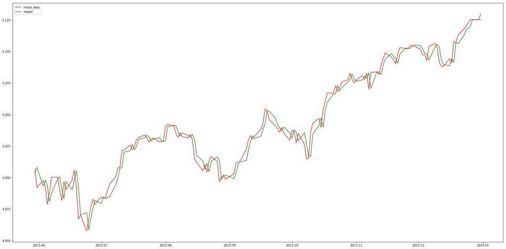

```python
sample_predict = best_model_fit.predict(typ='levels')

# plot last 150 elements
fig = plt.figure(figsize=(30, 15))
ax = fig.add_subplot(111)
ax.plot(ts_log[-150:], color='red', label='initial_data') # last 150 elements in ts_log
ax.plot(sample_predict[-150:], color='green', label='model') # last 150 elements (using the model)
plt.legend(loc='best')
plt.show()
```